# Statistical analysis plan for calibration of the Trident trial to a population-based cohort in Scotland.

Dr Alice Hosking, Prof Rustam Al-Shahi Salman, Prof William Whiteley, Prof David McAllister

2026-06-09

## 1 Introduction

### 1.1 Purpose and scope of this document

This statistical analysis plan details the analyses planned for calibration of the TRIDENT trial to a population-based inception cohort, including a worked-through example with mock values of hazard ratios.

### 1.2 Study overview

Intracerebral haemorrhage causes around a third of strokes worldwide but half the death and disability after stroke.<sup>1</sup> Those with ICH have an estimated 2% annual risk of recurrent ICH and 2% annual risk of ischaemic stroke.<sup>2</sup> A single-pill combination of three blood pressure lowering medicines at half standard dose (telmisartan 20 mg, amlodipine 2.5 mg, and indapamide 1.25 mg) in addition to standard care could reduce the risk of recurrent stroke after ICH. TRIDENT was an international, double-blind, placebo-controlled, randomised trial in adults with ICH and mild-moderate hypertension (systolic BP: 130–160 mmHg). The primary outcome was any stroke; secondary outcomes include recurrent ICH, cardiovascular events, and safety.<sup>3</sup>

### 1.3 Objectives

The aim of this study is to calibrate the effect of a low-dose triple pill antihypertensive medication in people with ICH from the TRIDENT trial to a population-based cohort in Lothian, Scotland.

The outcome will be:

- A measure of relative effect, the risk ratio, calibrated to the Lothian population.
- A measure of absolute effect, the number needed to treat, calibrated to the Lothian population.

## 2 Study design, population and outcomes

### 2.1 Study design

This study will use stratified data from the TRIDENT trial (the trial population) and data from the LATCH study (the target population), a prospective, population-based inception cohort study of people with ICH in NHS Lothian.

The TRIDENT trial result showed no difference in the primary outcome (recurrent stroke) until approximately 18 months, from which point the cumulative incidence function for the primary outcome appeared to diverge between control and treatment arms. We will therefore calibrate at two time points, 18 months ($t_1$) and end of follow up (approx 6 years, $t_2$).

There are various methods to calibrate trials. Regression-based approaches and inverse probability weighting require individual patient data.<sup>12</sup> Alternatively, one can stratify a trial and target population by key factors, and extract hazard ratios from the trial for each stratum, obviating the need for individual participant data access. We propose to use this method to calibrate TRIDENT to the LATCH population.

In summary, the method is:

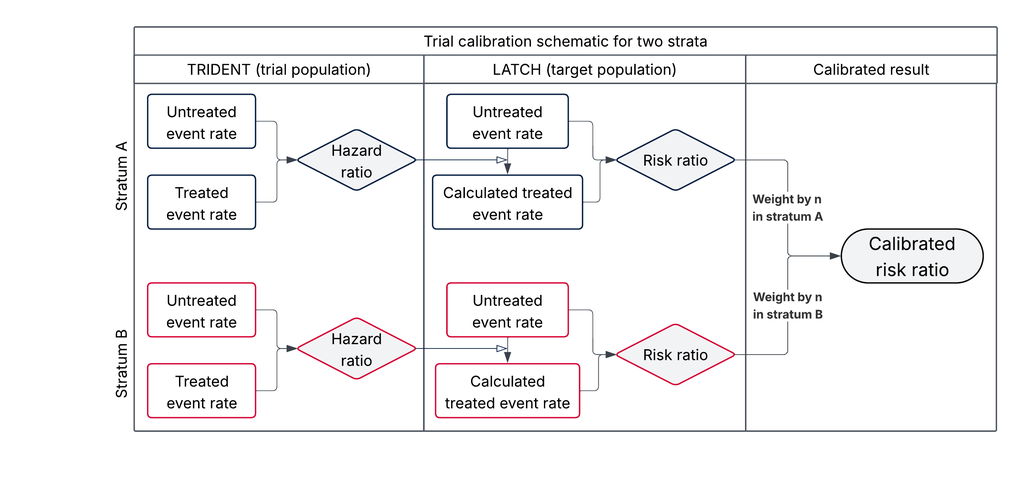

Figure 1: Flowchart schematic of trial calibration method using two strata.

### 2.2 Populations

#### 2.2.1 Trial population

The trial population is the 1670 people included in the TRIDENT trial, an international multicentre double-blind placebo-controlled trial. The average time to randomisation after ICH onset was 54 days. The primary outcome was time to first recurrent stroke.

TRIDENT Inclusion Criteria

- Adults (≥18 years) with a history of primary ICH that was confirmed by imaging.
- Clinically stable, as judged by investigator.
- An average of two resting systolic blood pressure (SBP) levels measured 5 minutes apart in the range 130-160 mmHg recorded in a seated position. Patients with higher SBP could still be included if it was considered by the site investigator that their management would be consistent with local standards of clinical practice.
- Geographical proximity to the recruiting hospital and/or follow-up medical clinic site to allow ready access for in-person assessments during follow-up.
- No clear contraindication or indication to any of the individual components of the Investigational Medical Product (IMP).
- Provision of written informed consent

TRIDENT Exclusion Criteria

- Taking an angiotensin converting enzyme inhibitor (ACE-I) that could not be switched to any of the following alternatives: an angiotensin receptor blocker (ARB) (e.g. telmisartan 20 or 40 mg), a calcium channel blocker (CCB) (e.g. amlodipine 2.5 or 5 mg), or a thiazide (TZ)-like diuretic (e.g. indapamide 1.25 mg); an equivalent class (ARB, CCB or TZ); or a beta-blocker (BB).
- Contraindication to any component of the IMP in the context of currently prescribed BP lowering treatment.
- Unable to complete the study procedures and/or follow-up.

#### 2.2.2 Target population

We aim to calibrate to a target population that reflects who might be prescribed the TRIDENT single pill, if it were recommended in clinical treatment guidelines.

The Lothian Audit of Intracerebral Haemorrhage (LATCH) was a population-based cohort study that ran between 1st June 2010 and 31st May 2013, and 1st November 2018 and 31st October 2021, with the aim of near-complete ascertainment of ICH in the Lothian Health board region of Scotland in residents aged ≥16 years. Approval for LATCH was granted by the Caldicott guardian of NHS Lothian. The LATCH audit has been described previously.<sup>13</sup> Prospective sources included a trust-wide network of physicians, neurologists, neurosurgeons, radiologists, pathologists, specialist nurses and audit personnel; and daily neuroradiology meetings and review of all computed tomographic (CT) head scans. Retrospective sources were electronic patient notes, International Classification of Diseases 10th Revision (ICD-10) coded hospital discharge records, the Scottish Stroke Care Audit,<sup>14</sup> and death records at the Office of the Procurator Fiscal.

#### 2.2.3 Assumptions and limitations

- We assume that the hazard ratios for each stratum reflect real variation in hazard by age and sex, rather than random variation around the mean.
- The trial and target populations are partially overlapping, as the Royal Infirmary of Edinburgh recruited 17 people with ICH for TRIDENT. Therefore approximately 9 people in the target population (1.5%) are on treatment. We cannot identify those treated, but assume this will make a negligible difference to the untreated rate.
- There were limitations to the maximum doses of additional blood pressure treatment for those in both treatment and placebo arms of TRIDENT. People in LATCH may have been prescribed doses in excess of this, but we do not have data on discharge medications for the whole LATCH population, so cannot exclude these people.

## 3 Analysis example

We now show the method for calibration through a worked example using real LATCH data, and mock hazard ratios (and their 95% confidence intervals) from TRIDENT. We create age/sex four strata for this example.

### 3.1 Time period definitions

We will calibrate at two time points, 18 months ($t_1$) and end of follow up (approx 6 years, $t_2$). The time period from start of follow-up to $t_1$ is $\tau_1$. The time period from $t_1$ to $t_2$ is $\tau_2$.

### 3.2 Data tidying

First we filter LATCH to only those who survived 7 days, format dates correctly, set censoring dates, and split into strata (under 65 and 65 and over, male and female). For this study, we censor LATCH follow up at the maximum TRIDENT follow-up time of six years.

### 3.3 Parametric survival model for LATCH

We model the event rate (stroke recurrence) in LATCH for each stratum. We use a parametric model.

First inspect the Kaplan Meier curve. This looks approximately exponential.

We model the event rate with a parametric survival model to select the most appropriate distribution, using the flexsurv package in R. There are various choices for the model distribution (exponential, gamma, Weibull etc). We compare the hazard and survival plots for each distribution to a non-parametric model (the kernel, in black), and the AIC for each distribution.

#### 3.3.1 Kaplan Meier curve

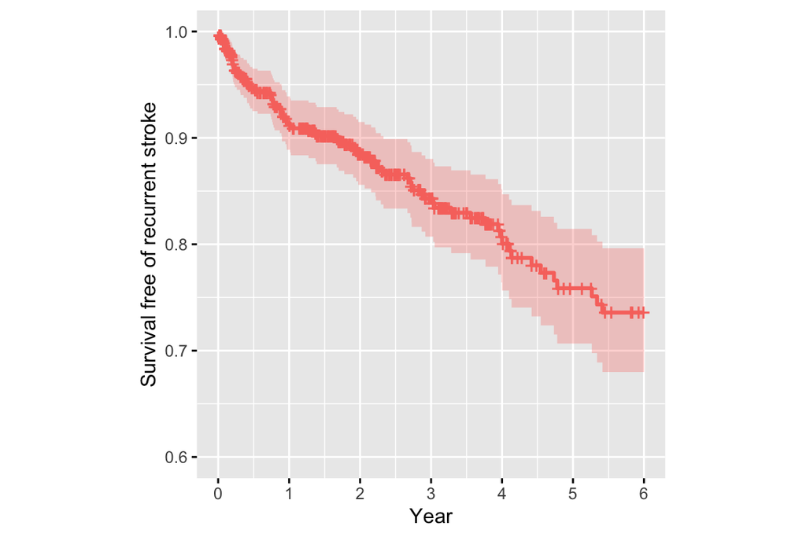

#### 3.3.2 Plot of survivals of various distributions

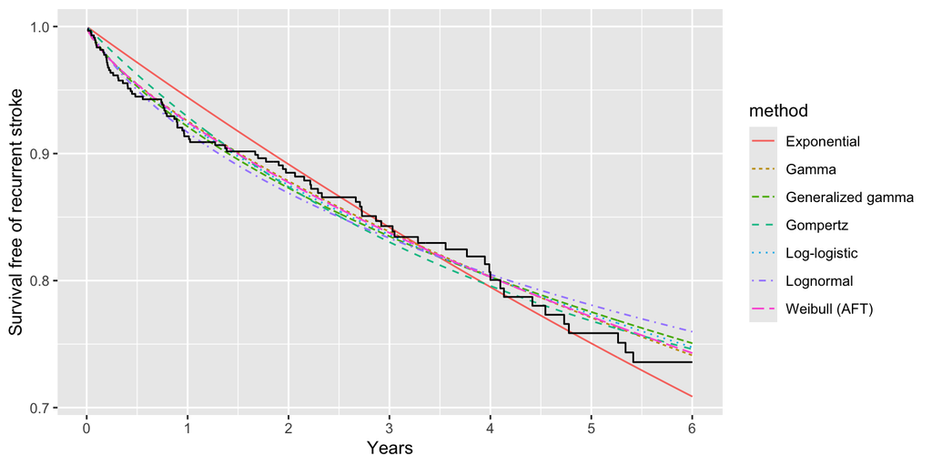

#### 3.3.3 Plot of hazards of various distributions

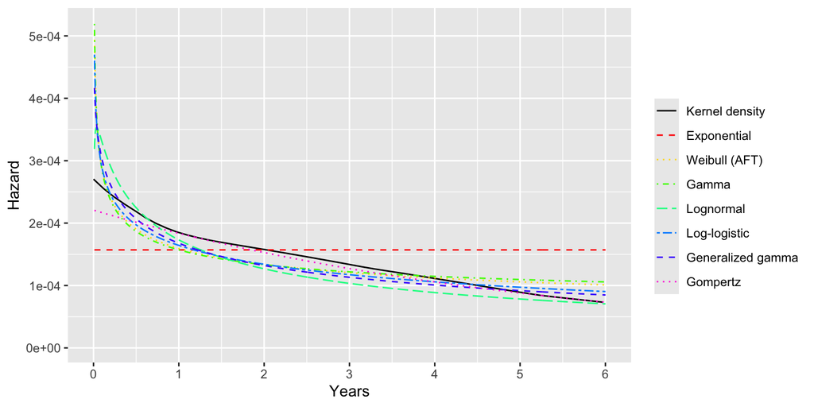

#### 3.3.4 Comparison of AIC

| Model | AIC |
| --- | --- |
| Exponential | 1602.43 |
| Weibull (AFT) | 1593.8 |
| Gamma | 1593.88 |
| Lognormal | 1594.16 |
| Log-logistic | 1593.95 |
| Generalized gamma | 1595.53 |
| Gompertz | 1598.55 |

### 3.4 Event rates in LATCH

The event rate is defined as:

$$\lambda_u=\text{rate in
untreated}$$
We define $n_s$ as the number of people in each stratum, and $m_s$ as the number of events per stratum.

$$\lambda_u=\frac{m_s}{\text{Total follow
up time for stratum}}$$
.

As we are assuming an exponential distribution, we can calculate the standard error directly:

$$ln(SE)=
\frac{1}{\sqrt{m_s}}$$
.

We can then simulate a normally distributed sample for the event rates.

#### 3.4.1 Table of event rates for each stratum

| N in stratum | log(rate/day) | log(standard error) | Events per 100 person years (95% CI) |
| --- | --- | --- | --- |
| 94 | -9.23 | 0.29 | 3.59 (2.04-6.33) |
| 34 | -9.37 | 0.50 | 3.11 (1.17-8.29) |
| 204 | -8.43 | 0.19 | 7.99 (5.55-11.49) |
| 269 | -8.69 | 0.16 | 6.13 (4.44-8.47) |

#### 3.4.2 Plot of log event rates for each stratum

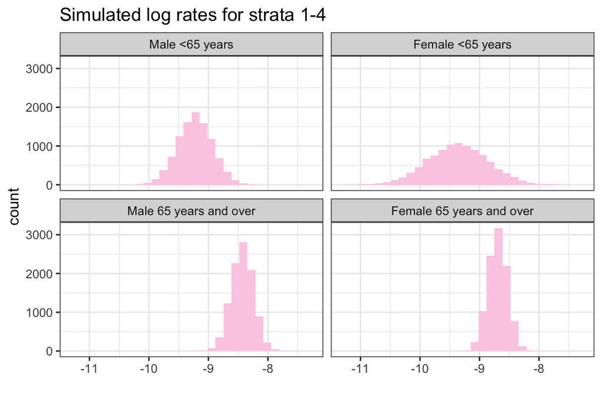

### 3.5 Hazard ratios for each stratum

For this mock-up we estimate hazard ratios for each time period (based roughly on published subgroup analysis). For the real analysis, the strata may be different; this is for demonstration only. We assume HR are independent; and make a guess at the HR for young men. We then split into two time periods: up to 18 months, where the HR are approximately 1; and beyond 18 months. We simulate 10,000 samples assuming a log normal distribution, for t1 and t2.

#### 3.5.1 Hazard ratio for period $\tau_1$

| Hazard ratio | Lower CI | Upper CI |
| --- | --- | --- |
| 0.82 | 0.68 | 1.22 |
| 0.87 | 0.75 | 1.27 |
| 0.90 | 0.82 | 1.13 |
| 0.92 | 0.84 | 1.17 |

#### 3.5.2 Hazard ratio for period $\tau_2$

| Hazard ratio | Lower CI | Upper CI |
| --- | --- | --- |
| 0.40 | 0.26 | 0.80 |
| 0.25 | 0.13 | 0.65 |
| 0.32 | 0.24 | 0.55 |
| 0.20 | 0.12 | 0.45 |

#### 3.5.3 Histogram of simulated log hazard ratios for strata 1-4, $\tau_1$

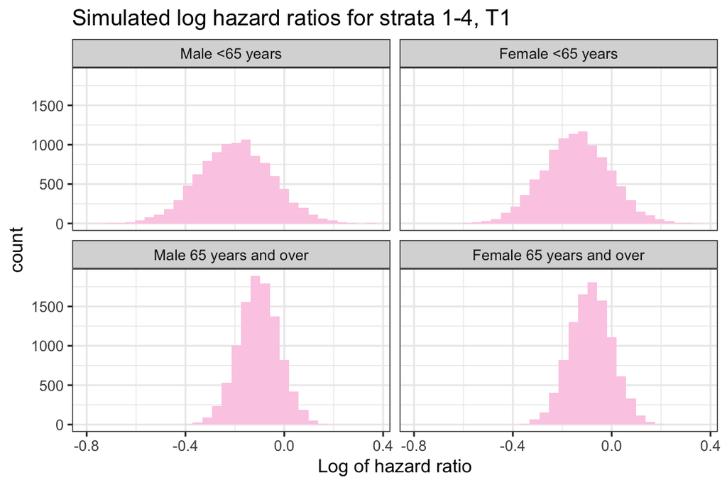

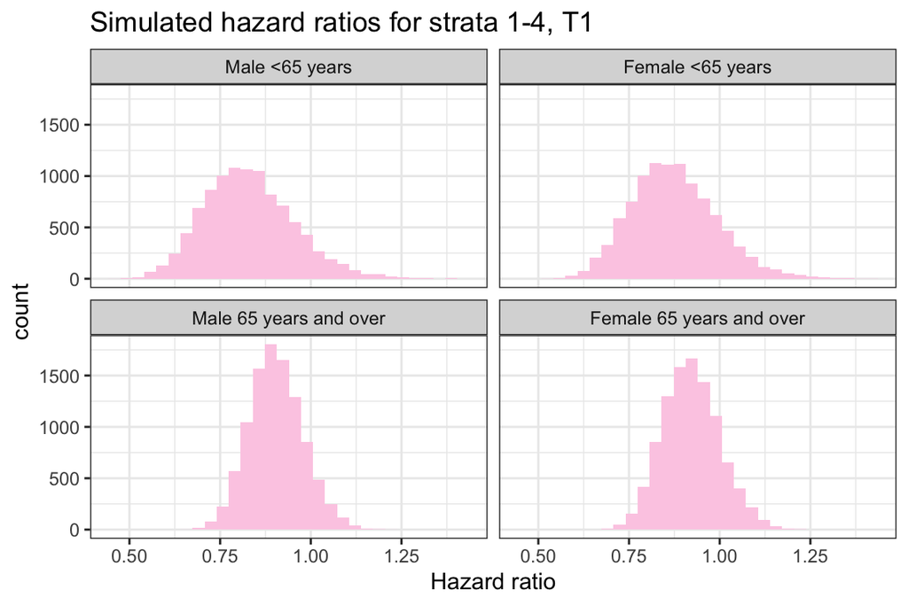

#### 3.5.5 Histogram of simulated log hazard ratios for strata 1-4, $\tau_2$

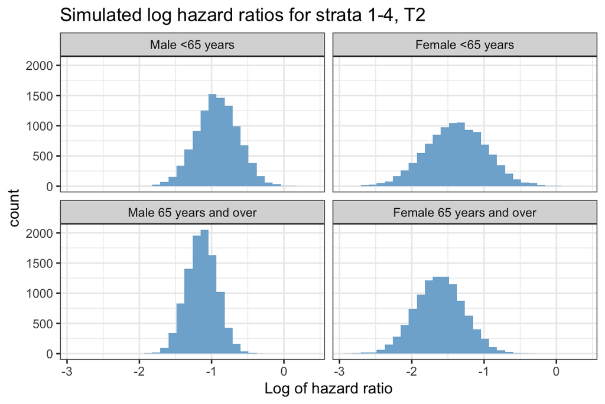

#### 3.5.6 Histogram of simulated hazard ratios for strata 1-4, $\tau_2$

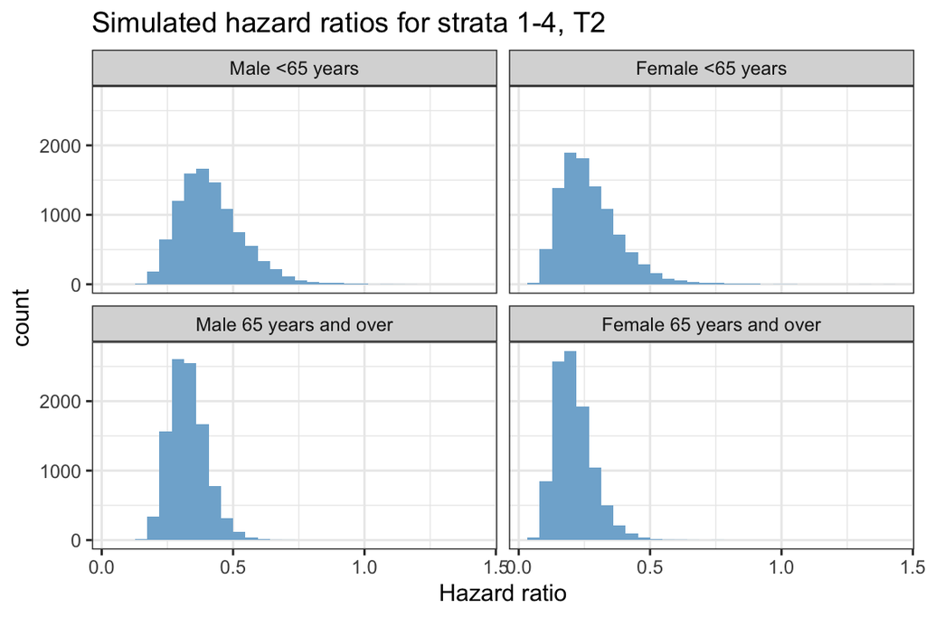

### 3.6 Calibrated rates and CIs for each stratum

For each age/sex stratum and for each time period, we combine the rate in the untreated and the hazard ratio to obtain a risk ratio.

Recall:

$$\lambda_u=\text{rate in
untreated}$$

Multiply untreated rates by hazard ratios ($HR$) to get treated event rates in each time period:
$$\lambda_{treat1} = \lambda_u
\times HR_1$$
$$\lambda_{treat2} =
\lambda_u \times HR_2$$

We then transform these to risks for each stratum:
$$R_{untreated} = 1 -
exp{(-\lambda_u(\tau_1+\tau_2)})$$

and

$$R_{treated} = 1 -
exp{(-(\lambda_{treat1} \tau_1 + \lambda_{treat2} \tau_2)})$$

The risk ratio at the end of the trial for each stratum is then:

$$RR_S=
\frac{R_{treated}}{R_{untreated}}$$

We have already simulated 10,000 samples for each hazard ratio and event rate, to generate 10,000 risk ratios.

#### 3.6.1 Simulated risk ratios for strata 1-4, $t_1$

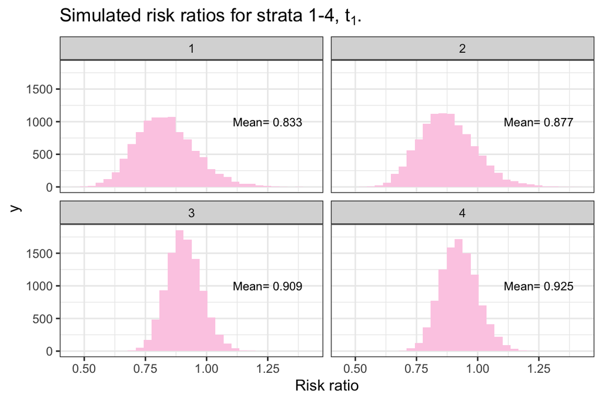

#### 3.6.2 Simulated risk ratios for strata 1-4, $t_2$

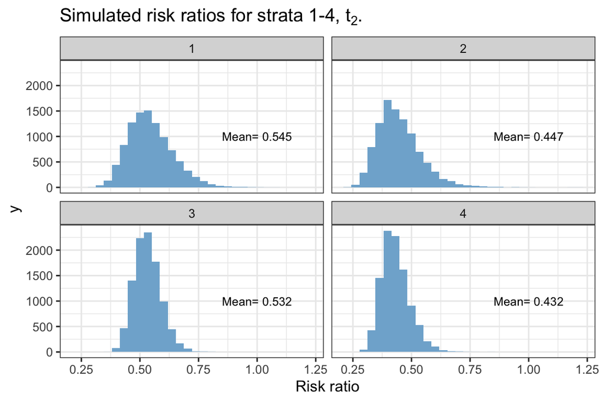

### 3.7 Pooled risk ratio

The final step is to pool the risk ratio for each stratum. We take a weighted mean, where the risk ratio for each stratum is weighted by the number of people in each stratum.

$$RR_{overall}= \sum_{s} RR_s n_s$$

We do this for all samples, then generate a mean and confidence intervals for the calibrated relative risk.

#### 3.7.1 Calibrated risk ratio at the end of the trial, for the whole trial

```
  The estimated calibrated risk ratio is 0.485 (95% confidence interval 0.42-0.564).
```

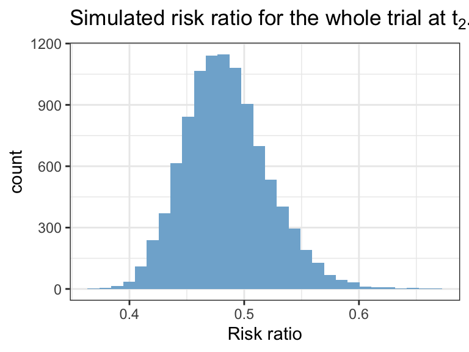

### 3.8 Absolute risk

We can use the new, calibrated risk ratio to estimate the number needed to treat (NNT) in the LATCH cohort from the absolute risk ratio (ARR). We use 10,000 samples of the risk ratio, and generate confidence intervals.

$$ARR = 1/(\lambda_u - \lambda_u \times
RR_{overall})$$

$$\text{NNT} = 1/\text{ARR}$$

```
 The number needed to treat is 33.99 (95% CI 30.06 - 39.96).
```

## 4 Extension to adverse events

Benefits of treatment must be balanced against potential risks, and so it might be informative to calibrate adverse events. In TRIDENT, adverse events of special interest were hypotension, syncope, headache, hyponatremia, hyperkalemia, injurious falls,and acute kidney injury. There was also a protocol requirement of discontinuation if serum creatinine increased level of 20% or more from the baseline value (creatinine was measured at baseline, 6 weeks and at the end of the trial).

Most of these adverse events were not measured in LATCH, but we have applied to link the LATCH cohort to routinely-collected data in Lothian, including renal function measurements. While a decline in renal function might not lead to discontinuation of a drug, it might have important implications for drug monitoring.

If sufficient people in LATCH have repeat measurements of renal function, we could apply a similar method to above, to calibrate the rate of decline in renal function to a specified threshold (eg >20% increase in creatinine, >30% decline in eGFR).

## 5 References

1.

Feigin VL, Abate MD, Abate YH, et al. Global, regional, and national burden of stroke and its risk factors, 1990–2021: A systematic analysis for the global burden of disease study 2021. *The Lancet Neurology*. 2024;23:973-1003. doi:10.1016/S1474-4422(24)00369-7

2.

Putri VP, Samarasekera N, Moullaali TJ, et al. Rates and risk factors for major adverse cardiovascular and cerebrovascular events after stroke due to intracerebral hemorrhage: Systematic review and study-level meta-analysis. *International Journal of Stroke*. October 2026. doi:10.1177/17474930261416692/SUPPL_FILE/SJ-DOCX-1-WSO-10.1177_17474930261416692.DOCX

3.

The Trident Research Group. Three low-dose antihypertensive agents in a single pill after intracerebral hemorrhage. *New England Journal of Medicine*. 2026;394:1571-1582. doi:10.1056/NEJMOA2515043

4.

Westreich D, Edwards JK, Lesko CR, Cole SR, Stuart EA. Target validity and the hierarchy of study designs. *American journal of epidemiology*. 2019;188:438-443. doi:10.1093/AJE/KWY228

5.

Bareinboim E, Pearla J. Causal inference and the data-fusion problem. *Proceedings of the National Academy of Sciences of the United States of America*. 2016;113:7345-7352. doi:10.1073/PNAS.1510507113

6.

Rothwell PM. External validity of randomised controlled trials: "To whom do the results of this trial apply?". *Lancet (London, England)*. 2005;365:82-93. doi:10.1016/S0140-6736(04)17670-8

7.

Sheppard JP, Lown M, Burt J, et al. Generalizability of blood pressure lowering trials to older patients: Cross-sectional analysis. *Journal of the American Geriatrics Society*. 2020;68:2508-2515. doi:10.1111/JGS.16749

8.

Sardar MR, Badri M, Prince CT, Seltzer J, Kowey PR. Underrepresentation of women, elderly patients, and racial minorities in the randomized trials used for cardiovascular guidelines. *JAMA Internal Medicine*. 2014;174:1868-1870. doi:10.1001/JAMAINTERNMED.2014.4758

9.

Carcel C, Reeves M. Under-enrollment of women in stroke clinical trials. *Stroke*. 2021;52:452-457. doi:10.1161/STROKEAHA.120.033227

10.

Cole SR, Stuart EA. Generalizing evidence from randomized clinical trials to target populations: The ACTG 320 trial. *American Journal of Epidemiology*. 2010;172:107-115. doi:10.1093/AJE/KWQ084

11.

Manke-Reimers F, Brugger V, Bärnighausen T, Kohler S. When, why and how are estimated effects transported between populations? A scoping review of studies applying transportability methods. *European journal of epidemiology*. 2025;40:255-273. doi:10.1007/S10654-025-01217-W

12.

Wei L, Phillippo DM, Shah A, Cleland JGF, Lewsey J, McAllister DA. Transportability of two heart failure trials to a disease registry using individual patient data. *Journal of clinical epidemiology*. 2023;162:160-168. doi:10.1016/J.JCLINEPI.2023.08.019

13.

Samarasekera N, Fonville A, Lerpiniere C, et al. Influence of intracerebral hemorrhage location on incidence, characteristics, and outcome: Population-based study. *Stroke*. 2015;46:361-368. doi:10.1161/STROKEAHA.114.007953/-/DC1

14.

Turner M, Barber M, Dodds H, Dennis M, Langhorne P, Macleod MJ. Agreement between routine electronic hospital discharge and scottish stroke care audit (SSCA) data in identifying stroke in the scottish population. *BMC health services research*. 2015;15. doi:10.1186/S12913-015-1244-Y

## 6 Appendix

We can pool the risk ratio at $t_1$, to find the calibrated relative risk after 18 months.

```
The estimated calibrated risk ratio is 0.902 (95% confidence interval 0.816-0.994)
```

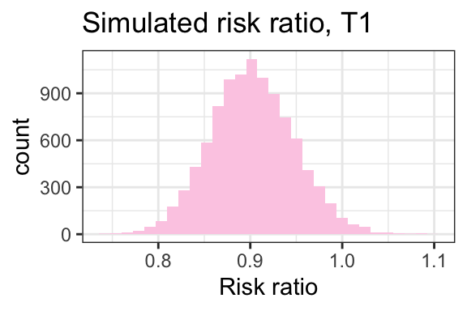

## 7 Extension: absolute risks in the prescence of competing risks.

To properly calculate absolute risk of recurrent stroke, we need to take into account competing risk of death. We earlier defined variables to allow us to calculate the rate of competing events.

### 7.1 Model selection

#### 7.1.1 KM curve

First, look at the Kaplan-Meier curve.

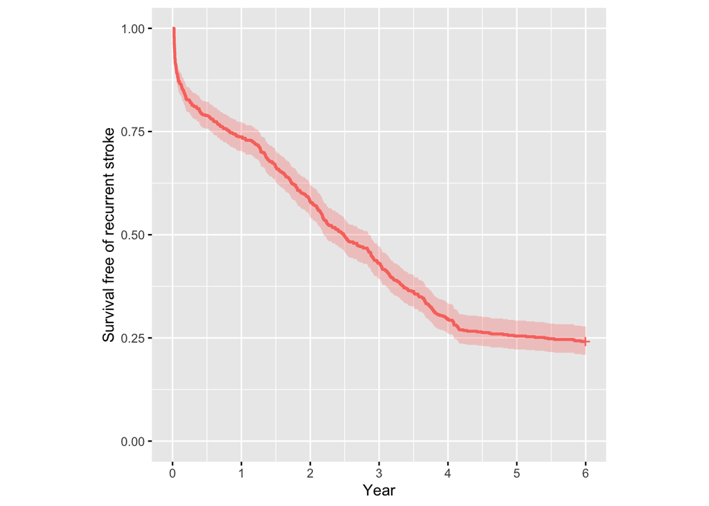

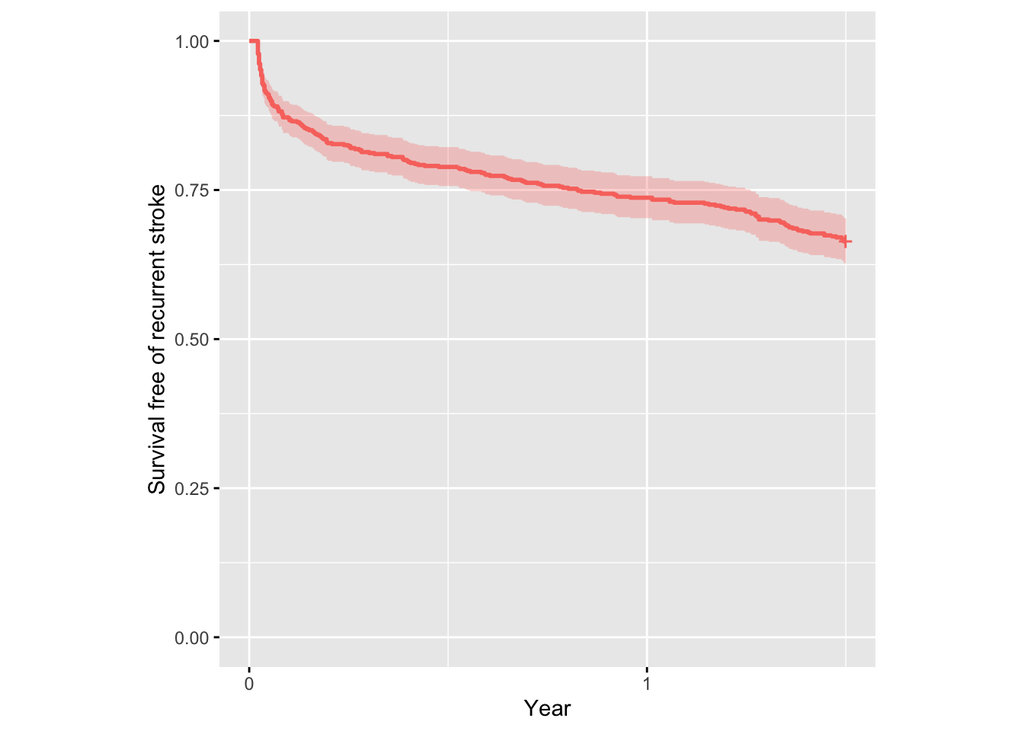

#### 7.1.2 Parametric model

Look to see if the exponential model is acceptable at t2. There appears to be a high early death rate until T1, which might be better fit by alternative model. To be discussed with David.

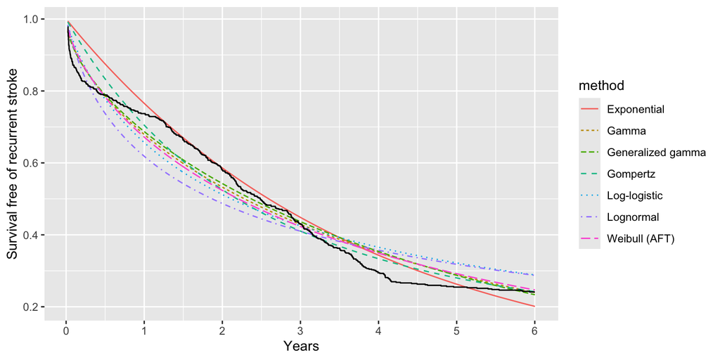

#### 7.1.3 Model selction at t1

What does it look like at t1?

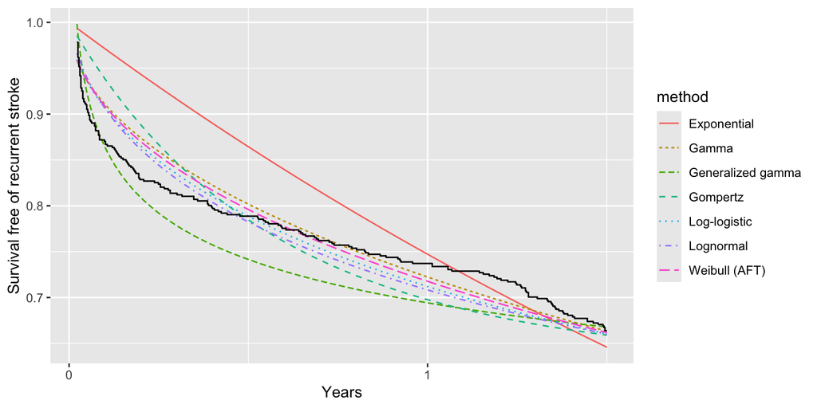

### 7.2 Rates of competing event (assume same for treated and untreated)

Assuming exponential event rate across $\tau_1$ and $\tau_2$, we can calculate the event rate, the standard error, and simulate a normally distributed sample. The tables shows the event rates for each stratum.

| N in stratum | log(rate/day) | log(standard error) | Events per 100 person years (95% CI) |
| --- | --- | --- | --- |
| 94 | -7.87 | 0.14 | 13.92 (10.61-18.27) |
| 34 | -7.78 | 0.22 | 15.29 (9.97-23.46) |
| 204 | -6.87 | 0.08 | 37.98 (32.74-44.07) |
| 269 | -7.16 | 0.07 | 28.37 (24.77-32.48) |

### 7.3 Calculate event rates accounting for competing risk

At this stage I haven’t simulated confidence intervals. The cumulative survival at each time point, taking into account competing risk of death, is

$$\text{cumulative survival} = 1 -
exp{(-\lambda_i t})-exp{(-\lambda_j t})$$
.

The cumulative incidence is then:

$$\text{cumulative incidence} =
\text{cumulative survival} \times \lambda_i / (\lambda_i +
\lambda_j)$$
At t1, this is as follows.

```
## $arms
## # A tibble: 1,098 × 3
##    obs.times arm   n1_cum_per
##        <dbl> <chr>      <dbl>
##  1         0 pl      0
##  2         1 pl      0.000165
##  3         2 pl      0.000330
##  4         3 pl      0.000495
##  5         4 pl      0.000660
##  6         5 pl      0.000825
##  7         6 pl      0.000989
##  8         7 pl      0.00115
##  9         8 pl      0.00132
## 10         9 pl      0.00148
## # ℹ 1,088 more rows
##
## $effects
## # A tibble: 548 × 4
##    obs.times       arr    rr    or
##        <dbl>     <dbl> <dbl> <dbl>
##  1         1 0.0000314 0.810 0.810
##  2         2 0.0000627 0.810 0.810
##  3         3 0.0000941 0.810 0.810
##  4         4 0.000125  0.810 0.810
##  5         5 0.000157  0.810 0.810
##  6         6 0.000188  0.810 0.810
##  7         7 0.000219  0.810 0.810
##  8         8 0.000251  0.810 0.810
##  9         9 0.000282  0.810 0.810
## 10        10 0.000313  0.810 0.810
## # ℹ 538 more rows
```

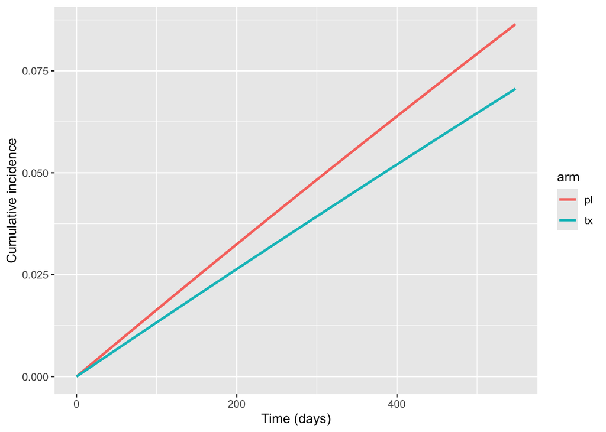

```
## $arms
## # A tibble: 4,384 × 3
##    obs.times arm   n1_cum_per
##        <dbl> <chr>      <dbl>
##  1         0 pl      0
##  2         1 pl      0.000165
##  3         2 pl      0.000330
##  4         3 pl      0.000495
##  5         4 pl      0.000660
##  6         5 pl      0.000825
##  7         6 pl      0.000989
##  8         7 pl      0.00115
##  9         8 pl      0.00132
## 10         9 pl      0.00148
## # ℹ 4,374 more rows
##
## $effects
## # A tibble: 548 × 4
##    obs.times       arr    rr    or
##        <dbl>     <dbl> <dbl> <dbl>
##  1         1 0.0000314 0.810 0.810
##  2         2 0.0000627 0.810 0.810
##  3         3 0.0000941 0.810 0.810
##  4         4 0.000125  0.810 0.810
##  5         5 0.000157  0.810 0.810
##  6         6 0.000188  0.810 0.810
##  7         7 0.000219  0.810 0.810
##  8         8 0.000251  0.810 0.810
##  9         9 0.000282  0.810 0.810
## 10        10 0.000313  0.810 0.810
## # ℹ 538 more rows
```

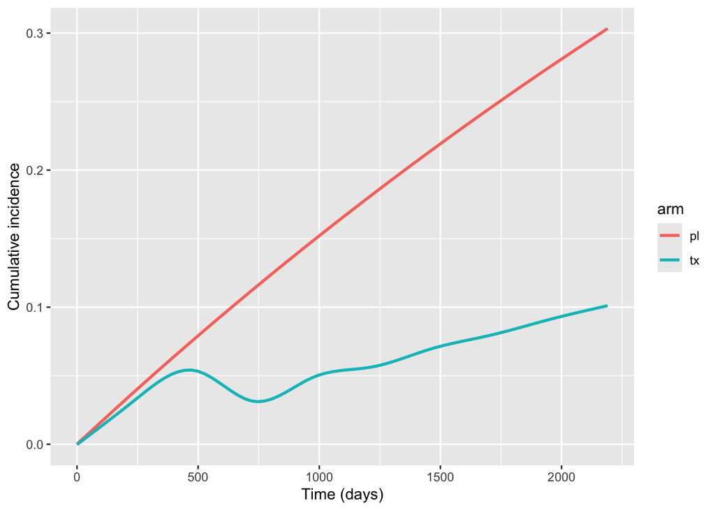

```
## [1] 0.08643961 0.07059437
```

```
## [1] 0.08643961 0.07059437
```

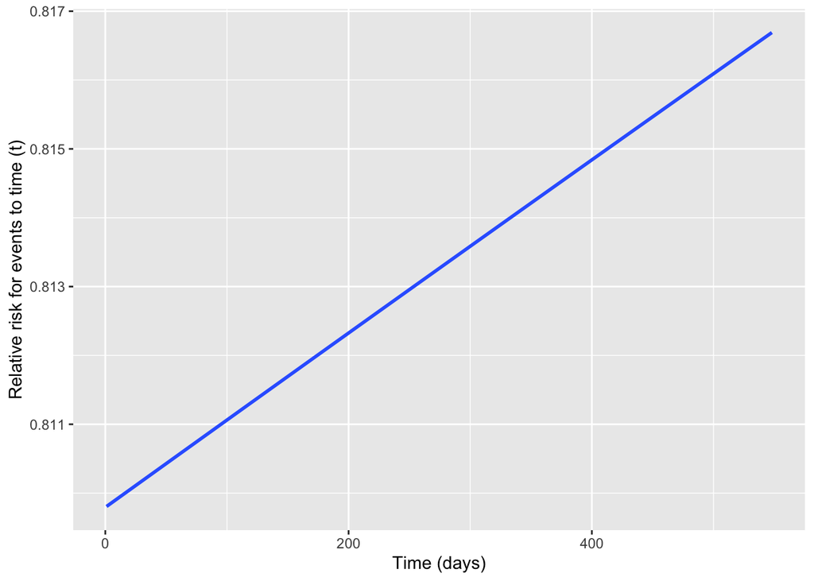

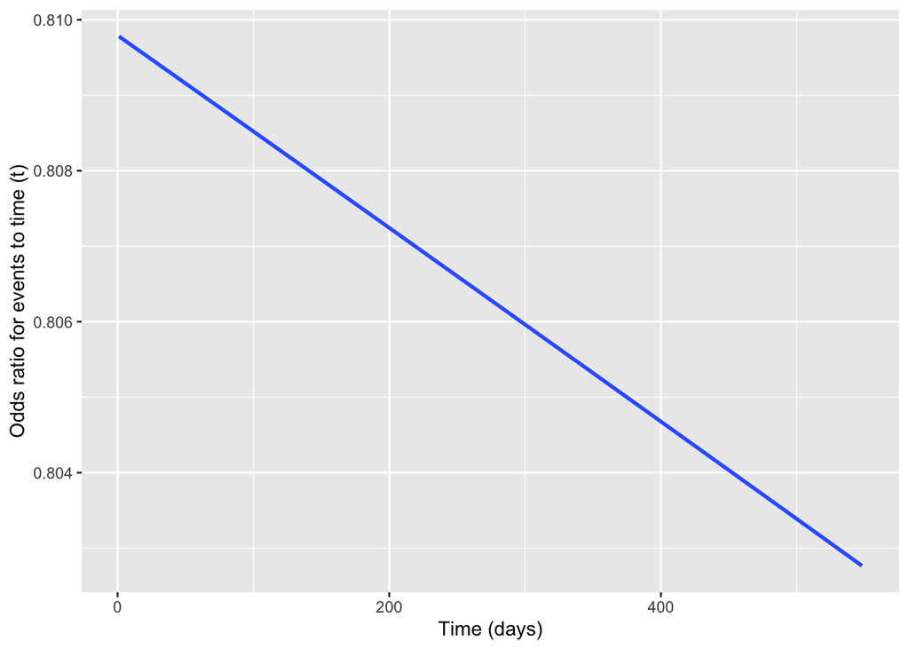